# Synthetic Control

Stats Who? A weekly blog.

Maude Elovitz

Thursday, May 13th, 2021

# Synthetic Control: Fake It ’till You Make It

Thank you for reading this week’s edition of *Stats Who?* with Maude Elovitz, undergraduate Data Science student at Simmons University. In *Stat’s Who?*, I write a blog post detailing a new statistical analysis topic, and the fun part is, I have never learned about it before, either, so I teach you all as I am learning, too! Everyone at *Stats Who?* believes in cohesive learning, especially in academia, so feel free to send your questions to ‘statswho@gmail.com’ and we will get back to you with an answer (hopefully… unless you outsmart us :) ).

## Let’s hear some background information…

Every person is living in their own created reality. **Whoa**. Commonly, people think “hm, I wonder what would have happened if x didn’t occur”, or “hm, I wonder if the Red Sox would have actually been so amazing if Mookie Bets was not on the team”. These questions are real-life causal inference! We (humans) try and measure real-life interventions day in and day out, all by pondering hypothetical situations.

Now, what does a hypothetical look like in real-life? **Trick question** it doesn’t exist. This is the purpose of a hypothetical, it can be created or modified based on data or your own creation, but it could never tell us a quantitiative story until 2003 where we met the beautifully wonderful *synthetic control method* brought to us by economists Alberto Abadie and Javier Gardeazabal.

Alberto Abadie is an economist and professor of Economics at the Massachusetts Institute of Technology (Alberto Abadie, n.d.). Javier Gareazabal is also an economist and economics professor at the University of the Basque Country UPV/EHU in Spain. In 2003, they wrote a paper called “The Economic Costs of Conflict: A Case Study of the Basque Country” where they investigated the interaction between conflict, politics, and economics. Specifically, Abadie and Gareazabal (2003) wanted to find out what the impact was of terrorism on the economy in the Basque country in Spain. They did this by creating a ‘“synthetic” Basque country without terrorism’ (116) to assess what the economy would look like without the treatment variable of terrorism. They created this synthetic country by using other countries in Spain who did not have terrorism, to create a fake Basque country without terrorism. They then compared the economic changes between the synthetic Basque country without terrorism with the Basque country during terrorism (Abadie & Gardeazabal, 2003).

**Thus, the synthetic control method was born!!**

## Why do we use synthetic control?

Since Abadie and Gareazabal used the method in 2003, it has become immensely popular. The estimation method is used very frequently in political science, specifically in policy analysis and evaluation. It is also commonly used in economics to study economic trends. The introduction of numerical data to policy evaluation helped to tell a story of if the policy intervention to the problem for the state, country, territory, etc. was actually helpful or harmful. Using this sort-of ‘matching procedure’ and creating a whole new synthetic control allowed for researchers to actually see what was happening pre and post policy intervention. Synthetic control analysis has been used in many large areas of economic policy analysis, such as minimum wage, immigration, and taxation (Abadie, 2020).

Synthetic Control works as follows: it assesses the outcome of an event on one aggregate unit (Abadie, 2020). For example, the effect of changing the drinking age to 21 on the number of motor vehicle related deaths for people under the age of 21 in the United States. As we can see here, policy interventions only happen once (when considering initial implementation of laws, not amendments). This is why synthetic control is optimal for policy analysis, because it uses time and comparison to other units that did not receive treatment to assess the *one* intervention that took place (Abadie, 2020).

### Now, let’s compare it with other analysis techniques

Regression analysis: - needs a lot of data to make an accurate prediction - not the best model for analyzing the impact of time on an outcome (Abadie, 2020)

Time-series analysis: - can be used for large scale policy evaluation, not medium or small scale - more used for analyzing short-term effects of an intervention (Abadie, 2020)

Synthetic Control: - evaluation over a long period of time (pre and post treatment) - set of control units and set of characteristics to predict outcome - can be used for small scale policy intervention (Abadie, 2020)

This is why synthetic control is superior to the two previously performed methods of analysis, because synthetic control does not require a lot of data (only a select few comparisons), and it can be used for small scale policy intervention analysis (Abadie, 2020).

**Synthetic Control is a comparative case study… or is it?**

When thinking about synthetic control, in the sense that the researcher is just comparing the synthetic version of the unit to the actual unit (state, territory, country, etc.), it’s easy to be confused on if it is actually a quantitative comparative case study. First, it is helpful to define what the goal of a comparative case study really is. Abadie, Diamond, and Hainmueller (2007) address that researchers attempt to estimate effects of interventions (treatments) on outcomes overtime, and gauge the effect of the treatment by comparing them to a similar control group who did not have the intervention. *So*, synthetic is a comparative case study, but on the unit itself. It is very helpful when there is limited aggregate comparable data (for example in policy studies) for finding a similar enough control group, because the control group is created synthetically through pre-treatment data.

### What are some drawbacks?

Synthetic control relies entirely on the assumption that the outcome relied entirely on the intervention of interest. We know this is the case because when you create the synthetic control unit (Oklahoma 2.0 for example), you are assuming that the outcome of interest did not receive the intervention, therefore you are looking at the difference between the two (treatment vs no treatment). This is definitely seen as an issue, because arguing that *that* is the only intervention that caused the outcome.

Another drawback to creating your synthetic control is that the model is determined by the pre-treatment data, so if your pre-treatment data is imperfect, then your synthetic model will be biased by other confounding variables (Ferman & Pinto, 2016).

## How do we use synthetic control?

Synthetic control is very similar to difference-in-difference, check out the analysis below to see an example and how to interpret the code!

Ferman and Pinto (2017, 2) write:

**“The main idea of the SC method is to use the pre-treatment periods to estimate weights such that a weighted average of the control units reconstructs the pre-treatment outcomes of the treated unit, and then use these weights to compute the counterfactual of the treated unit in case it were not treated.”**

Let’s break this down:

- “pre-treatment periods” means the time before the policy was implemented/event occurred
- “estimate weights…”
  - taking all of the weights in the donor pool, the potential comparisons (Abadie, 2020)
  - the synthetic control is the average of all of the weights in the donor pool (Abadie, 2020)
  - with these weights, you want them to be between 0 and 1, so we can limit extrapolation
    - extrapolation is not the best because you want your regression model to hold outside the model, so if you have extrapolation in your data, your results could limit reproducibility (12.8 - EXTRAPOLATION: Stat 501 n.d.)
- “reconstructs the pre-treatment outcomes” means we want these weights we averaged from the donor pool to show us an accurate representation of the unit pre-intervention
- “compute the counterfactual of the treated unit in case it were not treated”
  - building the model to show what would have happened if treatment DID NOT occur (using our synthetic control we created)

## Let’s visualize using a DAG!

First, we want to make a DAG (Directed Acyclic Graph) to display some causal assumptions in our potential synthetic control.

For this DAG, we will represent Scott Cunningham’s (2021) causal question of:

*“[What is] the effect of prison construction in 1993 on the incarceration of black men?”* (Cunningham 2021).

Now, we will represent the comparison (building prisons vs not building prisons) in the DAG!

```r
library(ggdag)
```

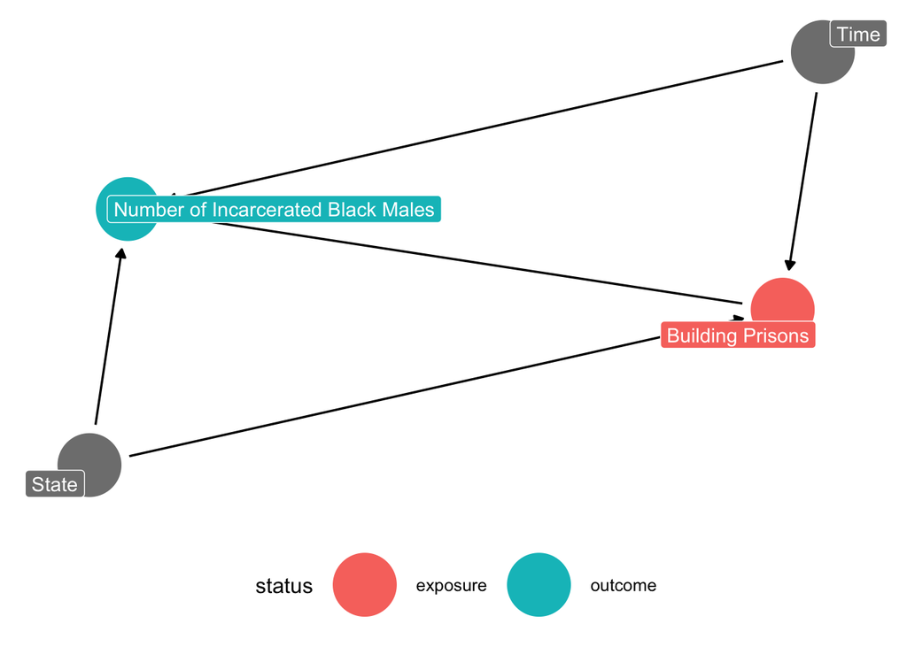

```r
economy_terrorism <- dagify(y ~ x + x2 + z,
                 z ~ x + x2,
                 labels = c("y" = "Number of Incarcerated Black Males",
                            "x" = "Time",
                            "x2"= "State",
                            "z" = "Building Prisons"),
                 exposure = "z",
                 outcome = "y")


ggdag_status(economy_terrorism, text = FALSE, use_labels = "label", seed = 12) +
  theme_dag() +
  theme(legend.position = "bottom")
```

With DAG’s, we are able to see perceived causal relationships. There is an estimated causal relationship between Number of Incarcerated Black Males and Building more prisons in Texas, but the extra element (backdoor) we are assessing is time, and also the fact that the state we are looking at is Texas. This is the extra element in Synthetic Control that we do not have in Difference in Difference, we are assessing the treatment effect based on creating a synthetic non treated treatment unit, so this is a possible back door in our DAG. Time is representing the idea that the the number of incarcerated black males was changing while more prisons were being built, therefore time is a covariate.

## So, I want to run my own synthetic control, what do I need to know?

### Can I even use a synthetic control method?

Let’s talk about some conditions/contextual considerations:

1. Volatility vs effect: if the volatility of the intervention of interest (e.g. the security/not showing a consistent effect) is high, then this needs to be filtered out of the post-intervention data. A high volatility could discredit a small effect that the intervention of interest has, or it could even discredit a large effect if the inconsistency is more noticeable (Abadie, 2020). For example, if someone is testing economic impacts of a law passed in 2015, and they want to use a lot of post-intervention data, they should filter out certain economic aspects of 2020 data because of how inconsistent COVID-19 was for the world’s economy.
2. Comparison group: when creating your donor pool, it is important that the donors have not received the intervention of interest, or an intervention like the intervention of interest during the years that you plan to study the unit of interest (Abadie, 2020). Also, the units in the donor pool should not have had a huge change in the outcome of interest, too. For example, if you want to measure a law for Georgia prohibiting alcohol, you should not include New Orleans in your donor pool of other Southern states for comparison if your time period is during Mardi Gras, as they will most likely have a large influx of alcohol purchases at that time.
3. No anticipation! If there are other actions that work in ‘anticipation’ of the intervention of interest (e.g. everyone takes all of their money out of the banks if the stock market crashes), then you would want move your pre-intervention window back or your post-intervention window forwards, so you do not interact with that anticipation window (Abadie, 2020).
4. No interference: you need a clean slate, with a whole lot of independence. Your donor pool needs to not impact the intervention or unit of interest at all (Abadie, 2020)! For example, if a donor in the donor pool suffered/benefited because of the intervention of interest, you do not want ot include it in your donor pool, too (Abadie, 2020). No interference, 10 yard penalty!
5. Convex hull condition: The difference in characteristics in the synthetic control and the affected post-intervention unit must be small, as it is built to be a comparison (Abadie, 2020).
6. Time Horizon: Be patient, wait for the intervention to actually take effect in full swing. If you do not have sufficient post-intervention data, then just wait it out! (Abadie, 2020).

### Data

Data for synthetic control is hard to find, and normally requires a conglomeration of datasets produced by various organizations. For example, the data used by Abadie, Diamond, and Hainmueller (2007) to analyze the impact of California’s tobacco control program used all different data, including data from the United States Census, alcohol and cigarette data, and tobacco data.

You want your data to contain a whole lot of pre-intervention information. This will help to strengthen the credibility of the synthetic control you create. For example, if you are wanting to demonstrate the impact of a law passed in 2010, it would be best to have data for many years before that. Abadie and Gareazabal (2003) were looking at the terrorism window from the mid 1970s - mid 1980s, so their pre-intervention window was from the 1960s - mid 1970s. Essentially, use as much as you can find. You also want your data to contain a lot of post-intervention data, this is very important. Sometimes, with interventions, they can be projected to show change a good 10+ years after the intervention takes effect (policy related), or, an intervention’s effect might go away after a short amount of time. By having a large window of post-intervention data, you can get the “whole picture” of the impact on the unit of interest (Abadie 2020, pp. 34).

## Analysis

This is a mixed analysis - as this is just an info blog post! I will be walking through the parameters of the R code, and walking through a slightly adapted example from Causal Inference: The Mixtape. The data is investigating the “effect of prison construction in 1993 on the incarceration of black men” (Cunningham, 2021).

### Getting ready

The R package for synthetic control methods is called Synth. We have installed our packages and ran our packages below.

```r
library(tidyverse)
library(broom)
library(haven)
library(Synth)
library(devtools)
if(!require(SCtools)) devtools::install_github("bcastanho/SCtools")
library(SCtools)
```

Here, we load our dataset (from Causal Inference: The Mixtape)

```r
library(readr)
sc_texas <- read_csv("sc_texas.csv")
sc_texas <- as.data.frame(sc_texas)
```

Here, we have to prepare the data using the dataprep() function from the Synth package. The dataprep() function makes a lists of matrices from the data that will be loaded into synth() because that is what synth() requires (Diamond & Hainmueler, 2014).

### Data preparation

Code retrieved from: (Cunningham, 2021, Synthetic Control)

```r
#Code retrieved from: (Cunningham, 2021, Synthetic Control)

dataprep_out <- dataprep(
  #the parameter 'foo' chooses the df to be used, in this case Texas
  foo = sc_texas,
  #the predictors must be numeric, they are the predictor variables
  predictors = c("poverty", "income"),
  #chooses how the predictors will predict, in this case it will be the mean (the operation)
  predictors.op = "mean",
  #the time period in question (pre and post intervention)
  time.predictors.prior = 1985:1993,
  #choosing specific predictors - listed here because you elaborate on when specifically these predictors will be predicting (the specified years)
  special.predictors = list(
    list("bmprison", c(1988, 1990:1992), "mean"),
    #this was initially alcohol in Cunningham's code, I changed it to crack to see if there was a different result
    list("crack", 1990, "mean"),
    list("aidscapita", 1990:1991, "mean"),
    list("black", 1990:1992, "mean"),
    list("perc1519", 1990, "mean"),
    #I also added in this special predictor out of curiosity, too.
    list("parole", 1990:1992, "mean")),
  #this identifies your dependent variable
  dependent = "bmprison",
  #this identifies what is going to be the ID for the donor pool, in this case the units will be the states
  unit.variable = "statefip",
  #identifies the name of the variable (still states)
  unit.names.variable = "state",
  #identifies the variable in the dataset that will represent time
  time.variable = "year",
  #this highlights texas (the statefip of texas is 48) as the treated case
  treatment.identifier = 48,
  #this highlights the control state FIPs that will be used as controls
  controls.identifier = c(1,2,4:6,8:13,15:42,44:47,49:51,53:56),
  #choosing the years
  time.optimize.ssr = 1985:1993,
  #the entire time period
  time.plot = 1985:2000
)
```

Now, what did this really do for us? Let’s take a closer look.

We assigned dataprep_out 4 matrices (X1, X0, Z1, Z0), that we will investigate further (Ye, 2019).

```r
#Code retrieved from (Ye, 2019)
as.data.frame(dataprep_out$X1)
```

```
##                                        48
## poverty                      1.722222e+01
## income                       1.648578e+04
## special.bmprison.1988.1992   2.260175e+04
## special.crack.1990           8.231856e-01
## special.aidscapita.1990.1991 1.421248e+01
## special.black.1990.1992      1.630466e+01
## special.perc1519.1990        7.703001e+00
## special.parole.1990.1992     1.163197e+05
```

```r
#Code retrieved from (Ye, 2019)
as.data.frame(dataprep_out$X0)
```

```
##                                         1            2            4
## poverty                      1.962222e+01    10.677778    13.966667
## income                       1.470433e+04 21701.000000 16171.777778
## special.bmprison.1988.1992   9.326250e+03   300.000000  2286.000000
## special.crack.1990           5.094361e-01    -1.166012     0.554759
## special.aidscapita.1990.1991 5.149180e+00     2.569788     8.387160
## special.black.1990.1992      2.572400e+01     5.050897     3.957660
## special.perc1519.1990        7.868362e+00     6.837102     7.110507
## special.parole.1990.1992     6.587333e+03   615.333333  3066.333333
##                                         5            6            8
## poverty                      2.003333e+01    14.322222    11.733333
## income                       1.379433e+04 20208.000000 18449.111111
## special.bmprison.1988.1992   3.728625e+03 31472.000000  1616.750000
## special.crack.1990           7.592691e-01     1.367013     0.132786
## special.aidscapita.1990.1991 3.899161e+00    21.372915    10.801443
## special.black.1990.1992      1.622366e+01    11.264852     4.683004
## special.perc1519.1990        7.611859e+00     6.938607     6.828298
## special.parole.1990.1992     3.630333e+03 78003.666667  2445.333333
##                                         9           10           11
## poverty                          6.666667     9.044444    18.633333
## income                       24479.666667 19924.555556 24073.333333
## special.bmprison.1988.1992    4528.000000  2172.000000  9234.000000
## special.crack.1990               2.812746     2.459503     1.700183
## special.aidscapita.1990.1991    11.188752    10.718576    86.718613
## special.black.1990.1992          8.926007    17.752010    70.690084
## special.perc1519.1990            6.415800     6.884897     6.689674
## special.parole.1990.1992       427.666667  1131.333333  5679.333333
##                                        12           13           15
## poverty                         14.055555    15.566667    10.055556
## income                       18156.888889 16526.000000 20244.333333
## special.bmprison.1988.1992   23441.000000 14152.500000   143.250000
## special.crack.1990               1.881816     2.028397     3.006470
## special.aidscapita.1990.1991    24.146843    14.838753    11.273244
## special.black.1990.1992         15.593873    28.000501     7.389296
## special.perc1519.1990            6.190002     7.638498     6.530722
## special.parole.1990.1992      8080.000000 23013.666667  1432.333333
##                                        16           17           18
## poverty                      1.462222e+01    13.900000 1.247778e+01
## income                       1.459067e+04 19485.111111 1.643533e+04
## special.bmprison.1988.1992   2.625000e+01 16285.000000 4.468750e+03
```

[output cut: 98 more lines]

```
## special.bmprison.1988.1992   10965.250000  1640.000000 2.152500e+02
## special.crack.1990               1.686802     1.919059 7.862515e-01
## special.aidscapita.1990.1991     7.943738     8.631021 2.812422e+00
## special.black.1990.1992         19.988495     3.442860 3.135099e+00
## special.perc1519.1990            7.049963     6.663495 7.875549e+00
## special.parole.1990.1992     10105.666667  8620.000000 1.008667e+03
##                                        55            56
## poverty                         10.022222    11.3777778
## income                       17070.111111 16657.7777778
## special.bmprison.1988.1992    2987.500000    49.2500000
## special.crack.1990               1.417225    -0.1855092
## special.aidscapita.1990.1991     2.875990     0.6532248
## special.black.1990.1992          5.276935     0.8115708
## special.perc1519.1990            7.078125     7.7131963
## special.parole.1990.1992      4612.666667   368.6666667
```

Next, we have Z1 which is the treatment case before the treatment (Ye, 2019). This shows you all of the years in question, and how many black men were in prison in Texas during those years.

```r
#Code retrieved from (Ye, 2019)
as.data.frame(dataprep_out$Z1)
```

```
##         48
## 1985 14828
## 1986 15207
## 1987 15780
## 1988 16956
## 1989 19366
## 1990 22634
## 1991 23249
## 1992 27568
## 1993 29260
```

```r
#Code retrieved from (Ye, 2019)
as.data.frame(dataprep_out$Z0)
```

```
##          1   2    4      5     6    8    9   10    11    12    13  15 16    17
## 1985  6227 198 1297 2153.0 16138  665 2620 1356  6021 13427  9043  98 31 10721
## 1986  6657 211 1452 2238.0 19549  786 2890 1545  6241 15486  9847 101 31 11103
## 1987  7281 217 1675 2536.0 22184  959 3070 1595  7126 16074 10865 109 25 11422
## 1988  7244 271 1775 2646.0 26438 1229 3541 1823  8205 17510 11429 140 23 11975
## 1989  8056 310 2033 3126.0 30066 1492 4172 2045  9320 20750 13001 137 24 14276
## 1990  9282 288 2283 3648.5 32190 1525 4818 2102  9222 23824 14025 132 27 16220
## 1991 10119 314 2432 4171.0 32981 1801 4856 2287  9513 25607 15031 145 29 17501
## 1992 10660 327 2654 4449.0 34279 1912 4897 2476  9996 26823 16125 156 26 19444
## 1993 11450 313 2865 4642.0 36461 2152 5873 2606 10023 29385 17713 152 47 21428
##        18   19   20   21    22 23    24   25    26   27   28   29 30  31   32
## 1985 3249  545 1556 1520  9562 15  9093 1740  9497  480 4156 3766 16 524 1123
## 1986 3216  525 1681 1645  9845 11  9333 1721 11174  514 4432 3942 16 539 1300
## 1987 3192  573 1829 1702 10585 15  9382 2001 12674  576 4542 4240 22 547 1245
## 1988 3367  629 1857 2058 11213 15 10031 2215 14939  707 4898 5369 17 593 1421
```

[output cut: 25 more lines]

```r
#Code retrieved from: (Cunningham, 2021, Synthetic Control), and (Diamond & Hainmueller, 2014)
synth_out <- synth(data.prep.obj = dataprep_out,
                   #this names which matrices will be the X1, X0, Z0, Z1 [see above for what these represent]
                   X1 = X1,
                   X0 = X0,
                   Z0 = Z0,
                   Z1 = Z1,
                   #use this to use a vector of custom weights, if you name the four above you do not need to use this (leave out)
                   custom.v = NULL,
                   #chooses the optimization algorithms to test, and then based on these R will choose the best optimization algorithem for you. Optimization chooses the best output with all of the inputs you have (Brownlee, 2020)
                   optimxmethod = c("Nelder-Mead", "BFGS"),
                   #if this is TRUE, there will be a two-step optimization procedure, where the problem will optimize using the chosen methods above, and then sent into genoud where it will be optimized again, and will use a quasi-Newton method that will work well on the hard optimization problems (Diamond & Hainmueller, 2014).
                   genoud = FALSE,
                   #solves quadratic programming (non linear programming) which solves more complicated programming problems. It tries to fit a quadratic model instead of a linear model (Heider, 2015). 'ipop' uses an interior point method (Karatzoglou, n.d.). You can also set this to LowRankQP which will solve a low rank quadratic programming problem, the default is ipop.
                   qudopt = "ipop",
                   #Sets the margin, "how close you can get to constraints" (Diamond & Hainmueller, 2014) from the quadratic programming model for the quadratic programming
                   Margin.ipop = 5e-04,
                   #Sets the significant figures for the optimization (default is 7) (Diamond & Hainmueller, 2014)
                   Sigf.ipop = 5,
                   #sets clipping bound for variables in ipop
                   Bound.ipop = 10,
                   #if TRUE, will show convergence information while the quadratic programming is going on
                   verbose = FALSE)
```

### Plot of our synthetic control

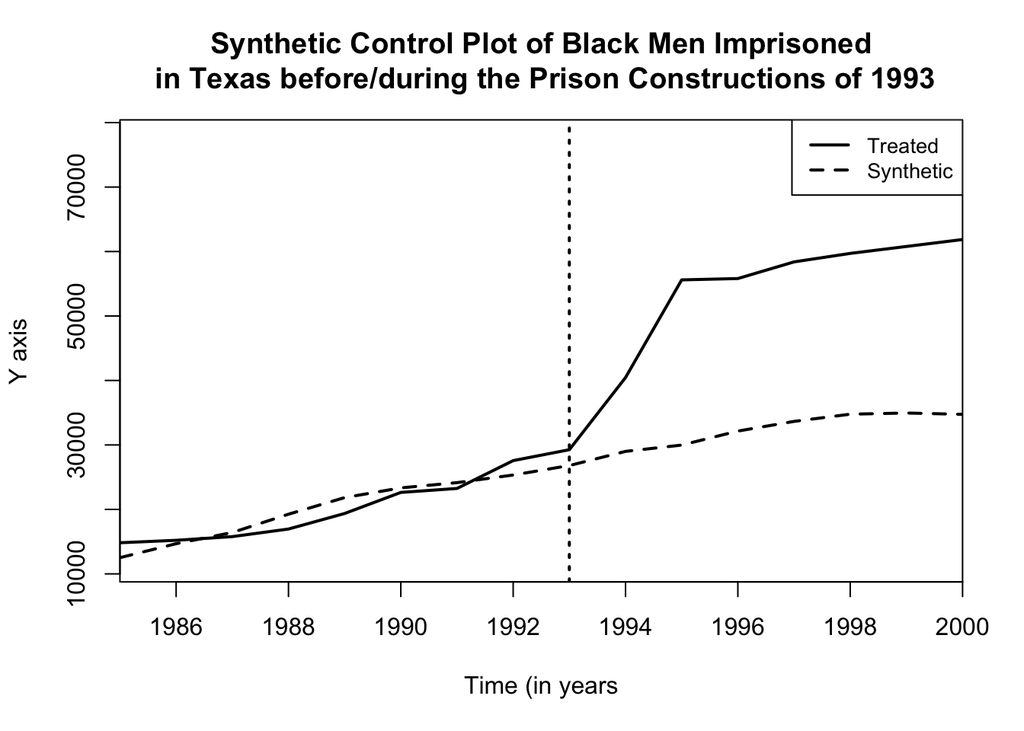

```r
#retrieved code from (Diamond & Hainmueller, 2014)
#plots the synthetic control vs the treatment on a plot
path.plot(synth_out,
          #chooses the matrices to plot
          dataprep_out,
          #adds a line to indicate when treatment started (year)
          tr.intake = 1993,
          #adds the y axis label
          Ylab = c("Y axis"),
          #adds the x axis label
          Xlab = c("Time (in years"),
          #sets the y axis limit (not needed)
          Ylim = NA,
          #adds labels to the legend
          Legend=c("Treated","Synthetic"),
          #sets the legend position
          Legend.position=c("topright"),
          #adds the main title
          Main = c("Synthetic Control Plot of Black Men Imprisoned\n in Texas before/during the Prison Constructions of 1993"),
          #if TRUE, it will only plot the pre-treatment, keep this one at FALSE to see both
          Z.plot = FALSE)
```

### Graph for Analysis

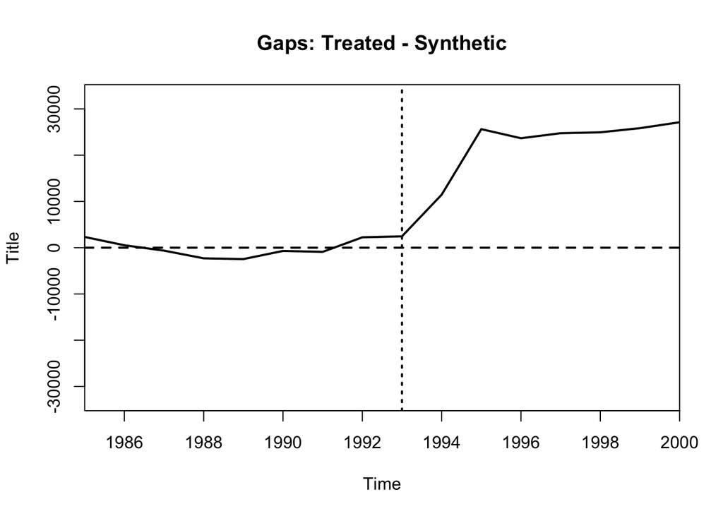

```r
#Code retrieved from (Cunningham, 2021)
gaps.plot(synth_out, dataprep_out, tr.intake = 1993)
```

When you calculate your synthetic control, you want to see where your gaps were. You want to have similar pre-treatment effects between the synthetic control unit and the treated unit (Cunningham, 2021), which we have here. When you have similar pre-treatment lines, this means that the synthetic control is actually a good model. If it was very different pre-treatment, then the synthetic control we have created would not mirror the treated unit as well. As for the post-treatment lines, it is best to see a gap here between the synthetic control unit and the treated unit (Cunningham, 2021), which we have, yay! This is because the synthetic control shows what would have happened if no treatment happened, and the treated unit shows what happened after treatment. If there is a gap, you can see that there was some sort of a change due to the intervention of interest, in this case the construction of prisons in 1993 in Texas.

### Tables for Analysis

Here, we will create some tables for analysis comparing the synthetic control and the treated group (texas)

```r
#Code retrieved from (Ye, 2019)
synth_tables = synth.tab(dataprep.res = dataprep_out,
                         synth.res = synth_out,
                         round.digit = 3)
```

Now, we have stored 4 different tables into the object synth_tables.

```r
synth_tables$tab.pred
```

```
##                                 Treated Synthetic Sample Mean
## poverty                          17.222    12.889      13.492
## income                        16485.778 19370.906   17480.102
## special.bmprison.1988.1992    22601.750 23019.444    6125.632
## special.crack.1990                0.823     2.025       1.346
## special.aidscapita.1990.1991     14.212    15.575       9.444
## special.black.1990.1992          16.305    10.507      11.424
## special.perc1519.1990             7.703     6.899       7.193
## special.parole.1990.1992     116319.667 72338.500    8989.123
```

This table shows you the differences between the synthetic control, the treatment unit, and the sample mean. We can see here that the synthetic control was close to predicting some of the predictors, but not all. They share similar special.perc1519.1990 values and similar special aidscapita.1990.1991 values. They have very dissimilar special.parole.1990.1992 values, and dissimilar poverty values.

```r
synth_tables$tab.w
```

```
##    w.weights           unit.names unit.numbers
## 1      0.000              Alabama            1
## 2      0.000               Alaska            2
## 4      0.000              Arizona            4
## 5      0.000             Arkansas            5
## 6      0.569           California            6
## 8      0.000             Colorado            8
## 9      0.000          Connecticut            9
## 10     0.000             Delaware           10
## 11     0.000 District of Columbia           11
## 12     0.000              Florida           12
## 13     0.000              Georgia           13
## 15     0.000               Hawaii           15
## 16     0.000                Idaho           16
## 17     0.000             Illinois           17
```

[output cut: 36 more lines]

### But, how do we evaluate our model?

This is from the SCTools package in R.

First, you need to generate placebos, which takes each unit in the donor pool, and acts as if it gives it the treatment that the original treatment unit had. This makes a synthetic control of each and every state that is in the donor pool, including Texas (Cunningham, 2021).

We create these placebos in order to calculate our p-value. The p-value tells us the proportion of placebos that had a ratio equal to or higher than the treated group. Because we are doing this test on all of the placebos (every unit in the donor pool), this test will show us the liklihood that obtaining our single treated unit’s result using a synthetic control method (Texas’s number of incarcerated black men) was due to chance, or if it required treatment (Silva, 2020).

So we would set up our hypotheses as follows (just for better comprehension and applicability purposes):

H0: pvalue < 0.05 [Treatment had an impact] HA: pvalue > 0.05 [Treatment had no impact]

Generating placebos

```r
#Code retrieved from (Silva, 2020)
placebos <- generate.placebos(dataprep_out,
                              synth_out,
                              Sigf.ipop = 3,
                              strategy = "sequential")
```

This plots our placebos and layers them with the original treated unit (Texas) so you can visualize where the other placebos fall.

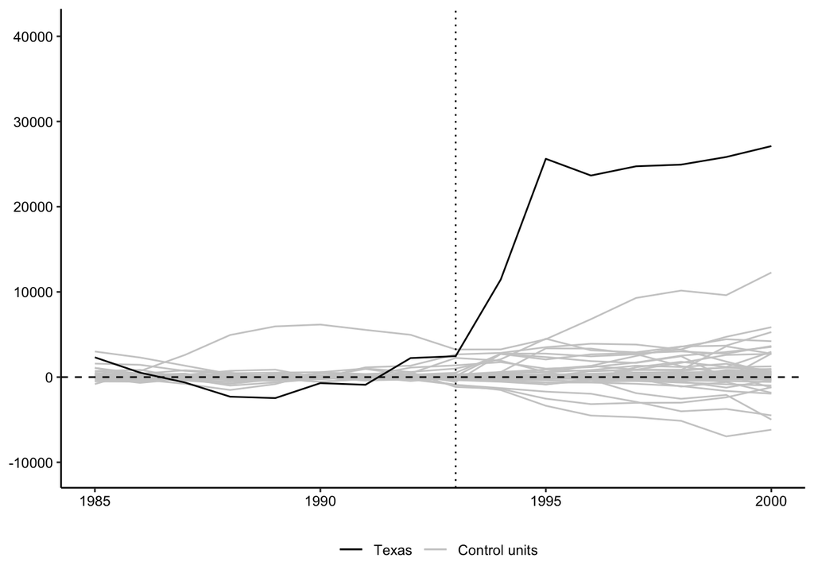

```r
plot_placebos(placebos)
```

**Running our actual test**

We are calculating the MSPE ratio of each placebo. MSPE stands for Mean Square Prediction Error Ratio, and shows the post-treatment/pre-treatment ratio. The authors of SCTools write that, “a higher ratio means a small pre-treatment prediction error [MSPE], and a high post-treatment MSPE, meaning a large difference between the unit and its synthetic control after the intervention” (Silva, 2020, pp. 10). This is what *you want* because it means treatment mattered!

```r
ratio = mspe.test(placebos, discard.extreme = TRUE, mspe.limit = 20)
ratio$p.val
```

```
## [1] 0.07843137
```

Now, we calculate our p.value. Our p-value in this case was 0.0784, meaning we fail to reject our null hypothesis, and do not have statistically significant evidence to say that treatment (building prisons in 1993) has an impact on the outcome (number of incarcerated black males).

*NOW, PLEASE NOTE*

In the actual example in Causal Inference: The Mixtape, Chapter 10, Synthetic Control, Cunningham’s p-value that he calculated (using slightly different predictors) got a p-value of 0.04 for Texas, meaning that there was statistically significant evidence to show that treatment mattered in Texas’s case.

You can also plot a histogram of the MSPE ratios for all of the placebos to see where your treated group (Texas) would fall among all of the other placebos.

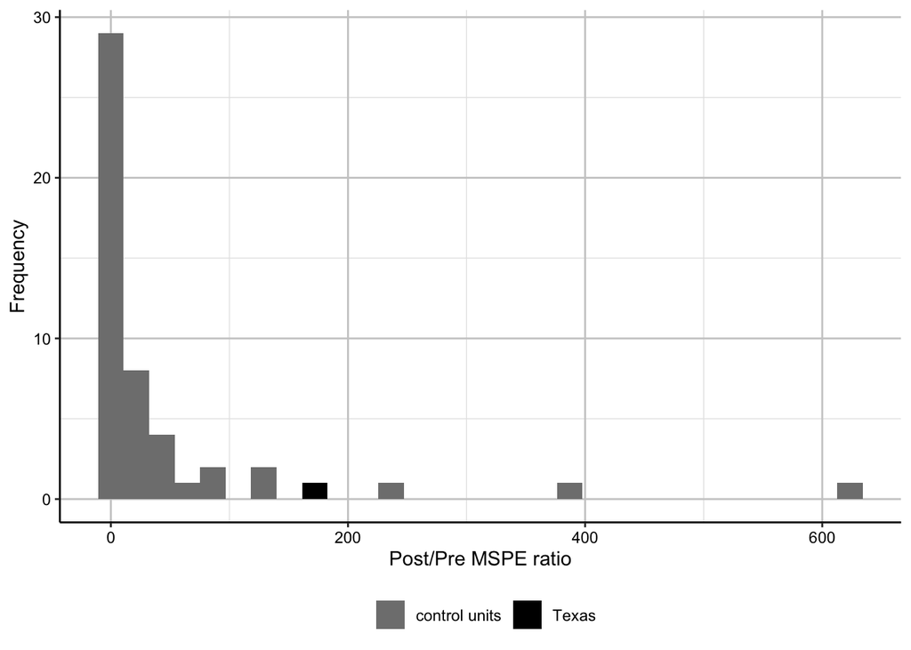

```r
mspe.plot(placebos, discard.extreme = TRUE, mspe.limit = 1, plot.hist = TRUE)
```

### Conclusion

Wow, you have made it! What a run-down, thank you for takign the time to learn about Synthetic Controls with me today. As we saw in our model evaluation, it really does depend on the model you create (your synthetic control) when testing for if there was an impact on the outcome due to treatment. Remember, comparative case studies can be so fun, and modeling them using statistical analysis is a great way to blend math and social sciences. The merging of these two fields is necessary in academia and various research fields, and should not be discounted. Please see my citations below to learn more, and as always, keep learning!!

### Citations

12.8 - EXTRAPOLATION: Stat 501. (n.d.). Retrieved May 12, 2021, from https://online.stat.psu.edu/stat501/lesson/12/12.8 Abadie, A. (2020, June). Using Synthetic Controls: Feasibility, Data Requirements, and Methodological Aspects. Retrieved from https://economics.mit.edu/files/17847

Abadie, A., & Gardeazabal, J. (2003). The Economic Costs of Conflict: A Case Study of the Basque Country. The American Economic Review, 93(1), 113-132.

Abadie, A., Diamond, A., & Hainmueller, J. (2007). Synthetic Control Methods for Comparative Case Studies: Estimating the Effect of California’s Tobacco Control Program. Journal of the American Statistical Association, 105(490), 493-505. doi:10.1198/jasa.2009.ap08746

Alberto Abadie. (n.d.). Retrieved from https://economics.mit.edu/faculty/abadie

Brownlee, J. (2020, December 20). How to choose an optimization algorithm. Retrieved from https://machinelearningmastery.com/tour-of-optimization-algorithms/

Cunningham, S. (2021). Synthetic control. In Causal inference: The mixtape. New Haven, CT: Yale University Press. Retrieved from https://mixtape.scunning.com/synthetic-control.html

Diamond, A., & Hainmueller, J. (2014, January 26). Synth package. Retrieved from https://www.rdocumentation.org/packages/Synth/versions/1.1-5

Ferman, B., & Pinto, C. (2021). Synthetic Controls with Imperfect Pre-Treatment Fit. Sao Paulo School of Economics - FGV.

Heider, J. (2015, June 7). Quadratic programming. Retrieved from https://optimization.mccormick.northwestern.edu/index.php/Quadratic_programming

Karatzoglou, A. (n.d.). Ipop: Quadratic programming solver. Retrieved from https://www.rdocumentation.org/packages/kernlab/versions/0.9-29/topics/ipop

Silva, B. C. (2020, August 26). SCtools. Retrieved from https://www.rdocumentation.org/packages/SCtools/versions/0.3.1

Ye, L., Ph. D. (2019, December 27). Causal inference using synthetic control: The ultimate guide. Retrieved from https://towardsdatascience.com/causal-inference-using-synthetic-control-the-ultimate-guide-a622ad5cf827